# Analysis of SE_CCA Summarized Experiment.

Nasim Bondar Sahebi

2023-12-20

# Load libraries.

```r
library(SummarizedExperiment)
library(dplyr)
library(ggplot2)
library(knitr)
library(DT)
library(limma)
library(EnhancedVolcano)
```

# Data Loading and Preparation

## Load Gene Summarized Experiment Data

#### Data Overview

Load the Summarized Experiment .rds file (SE_CCA.rds), extract clinical and expression data (TPM), along with annotations, and prepare the gene expression data for analysis.

```r
# Load your SE result and extract clinical data , expression data and annotation

# Load SE obj
se <- readRDS("~/BHK lab/kevin Project/Cholangiocarcinoma/data/SE_CCA.rds")

# Extract Clinical data
clin <- data.frame(colData(se)) #dim is 33 x 11

# Extract the expression data
expr_tpm <- assays(se)[["expr_tpm"]] #dim 38040 x 33

# Extract the annotation
annot <- data.frame(rowData(se))  #dim is 38040 x 11

# Display first few rows of the dataset
DT::datatable(expr_tpm[1:8, 1:8])
```

|  | BTC_0004 | BTC_0009 | BTC_0010 | BTC_0011 | BTC_0012 | BTC_0013 | BTC_0014 | BTC_0015 |
| --- | --- | --- | --- | --- | --- | --- | --- | --- |
| A1BG | 1.066800801901423 | 2.455178060122074 | 0.8209541835319744 | 3.673670048709614 | 0.6927896118395158 | 0.9213433981431819 | 0 | 0.7119203838757673 |
| A1BG-AS1 | 0 | 0.5999623391637627 | 1.4942415035962 | 2.005468976740089 | 0.0538106133286148 | 0.7952474508047976 | 0 | 0.4186929815764709 |
| A1CF | 2.034867528158554 | 4.800219201348203 | 4.489082450802559 | 1.875680210964469 | 2.086316376792373 | 0.5573051898161323 | 0 | 3.450297126509298 |
| A2M | 6.053288555445643 | 5.403463556944399 | 4.395730782707476 | 7.086129259726618 | 4.524381487655585 | 6.119561132257908 | 6.114406548590566 | 6.785152395620258 |
| A2M-AS1 | 0.06156470199764678 | 0.570344401716024 | 0.9686268003280635 | 1.405998892619721 | 1.392308079580622 | 0.4365669739364474 | 0 | 0.16347554592626 |
| A2ML1 | 4.445891737905109 | 0.03003656003684799 | 0.2260682556868633 | 3.419731013340841 | 0.7966259930531006 | 3.264640013084647 | 0 | 0.0719726752717269 |
| A2ML1-AS1 | 0 | 0 | 0 | 0 | 0 | 0.3297975578411688 | 0 | 0 |
| A2ML1-AS2 | 0 | 0 | 0 | 0 | 0 | 0 | 0 | 0 |

# Data Preparation

Preparing expression data (RNA-seq) for analysis:

1. **Restrict expression data to protein-coding genes.**
2. **Remove low/zero expression genes.**

```r
# Step 1: Restrict to Protein-Coding Genes.
annot_proteincoding <- annot[annot$gene_type == "protein_coding",] # 19205 protein coding genes.
expr_tpm<- expr_tpm[rownames(expr_tpm) %in% rownames(annot_proteincoding),]
dim(expr_tpm)
```

```
## [1] 19205    33
```

```r
# Step 2: Filter Low/Zero Expression Genes]

#data is log2(TPM+1)
r <- as.numeric(apply(expr_tpm, 1, function(i) sum(round(i, 6) == round(log2(1), 6))))

# Get the indices of rows to remove
remove <- which(r > dim(expr_tpm)[2] * 0.05)

# Remove rows from the matrix
expr_tpm <- expr_tpm[-remove, ]   #dim is 6789 x 33

dim(expr_tpm)
```

```
## [1] 6789   33
```

```r
# transpose the expr_tpm for later use in pCA.
#expr_tpm <- t(expr_tpm)

DT::datatable(expr_tpm[1:8, 1:8])
```

|  | BTC_0004 | BTC_0009 | BTC_0010 | BTC_0011 | BTC_0012 | BTC_0013 | BTC_0014 | BTC_0015 |
| --- | --- | --- | --- | --- | --- | --- | --- | --- |
| A2M | 6.053288555445643 | 5.403463556944399 | 4.395730782707476 | 7.086129259726618 | 4.524381487655585 | 6.119561132257908 | 6.114406548590566 | 6.785152395620258 |
| A4GALT | 1.304840429307654 | 3.065161260724778 | 3.887160749237565 | 3.277456356447737 | 5.142767696096551 | 4.181361003835891 | 4.494377718353118 | 4.472727160993704 |
| AACS | 5.183061821627084 | 4.261527279959256 | 4.630826487339994 | 4.719618593329912 | 5.444388087469667 | 5.042811270677618 | 3.853020351064825 | 3.776483251176402 |
| AAGAB | 4.796412162276444 | 5.153664423280214 | 3.491723055556064 | 5.291256728818609 | 5.892785697173539 | 4.796017642048279 | 5.428633760471806 | 4.172338693905069 |
| AAK1 | 3.940309697091813 | 3.771102022497884 | 4.304266507641128 | 4.194792463438541 | 3.86553929032372 | 4.185189429533327 | 2.551516263716699 | 4.298668431988174 |
| AAMP | 6.462159371437003 | 6.344810321197393 | 4.609127428269955 | 5.564876775605661 | 6.73040016605167 | 6.742829958846973 | 4.874380668162264 | 5.917059528337086 |
| AARS1 | 7.712377963547953 | 7.26493519061443 | 3.406714751236565 | 5.421149260303284 | 6.814622364163341 | 5.736296010273881 | 5.827959401158987 | 4.561399277588579 |
| AATF | 5.675574078862986 | 5.459040201726165 | 4.935062527668282 | 5.296020274304033 | 5.718647533661212 | 5.28477850687149 | 4.484252033860542 | 4.68082189954816 |

# Descriptive analysis

## Evaluate Differences in Clinicodemographic and Staging Variables

- **Continuous Variables (e.g., Age):** We calculated the median and IQR and assessed associations using the Wilcoxon test.
  - *Reason:* The Wilcoxon test is used because it’s non-parametric and effective for data not normally distributed.
- **Discrete/Categorical Variables (e.g., Sex, Stage, Location):** We determined frequency and percentage distributions and assessed associations using Fisher’s exact test.
  - *Reason:* Fisher’s exact test is preferred over chi-squared in small samples because it’s more accurate with low frequencies (less than 5).

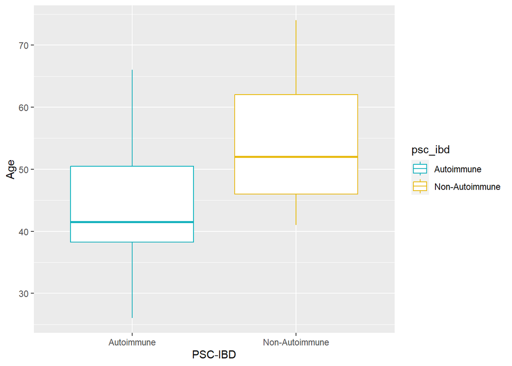

```r
# Set 'y' and 'n' to 'Autoimmune' and 'Non-Autoimmune' within the dataframe
clin$psc_ibd[clin$psc_ibd == 'y'] <- 'Autoimmune'
clin$psc_ibd[clin$psc_ibd == 'n'] <- 'Non-Autoimmune'

# 1. Age

# Summarize age statistics (count,Mean(SD), Median(IQR), Min,Max) for each psc_ibd group.
summary_stats <- summarise(
  group_by(clin, psc_ibd),
  count = n(),
  Mean_SD = sprintf("%.2f(%.2f)", mean(age, na.rm = TRUE), sd(age, na.rm = TRUE)),
  Median_IQR = sprintf("%.2f(%.2f)", median(age, na.rm = TRUE), IQR(age, na.rm = TRUE)),
  Min_Max = sprintf("%.2f,%.2f", min(age, na.rm = TRUE), max(age, na.rm = TRUE))
)

# Store statistics for Auto and Non-Auto for later use
auto_count <- summary_stats$count[summary_stats$psc_ibd == "Autoimmune"]
non_auto_count <- summary_stats$count[summary_stats$psc_ibd == "Non-Autoimmune"]

# Visualize your data.

# Plotting boxplot for age distributions
ggplot(clin, aes(x = psc_ibd, y = age, color = psc_ibd)) +
  geom_boxplot() +
  scale_color_manual(values = c("Autoimmune" = "#00AFBB", "Non-Autoimmune" = "#E7B800")) +
  labs(y = "Age", x = "PSC-IBD")
```

```r
# Perform two-sample Wilcoxon test
res <- wilcox.test(age ~ psc_ibd, data = clin, exact = FALSE)
p_value_age <- round(res$p.value, 2)

# 2. Sex

# Perform Fisher's Exact Test for 'sex' and 'psc_ibd'
contingency_sex <- table(clin$sex, clin$psc_ibd)
p_value_sex <- round(fisher.test(contingency_sex)$p.value,2)

# Calculate and format percentages for Sex
sex_stats <- apply(contingency_sex, 2, function(x) sprintf("%d (%.1f%%)", x, 100 * x / sum(x)))

# Perform Fisher's Exact Test for 'location' and 'psc_ibd'
contingency_loc <- table(clin$location, clin$psc_ibd)
p_value_loc <- round(fisher.test(contingency_loc)$p.value, 2)

# Calculate and format percentages for Location
location_stats <- apply(contingency_loc, 2, function(x) sprintf("%d (%.1f%%)", x, 100 * x / sum(x)))

# Perform Fisher's Exact Test for 'stage' and 'psc_ibd'
# TODO: Convert "IIIA", "IIIB", "IIIC" to "IIIA and convert "IVA", "IVB" to "IV".
clin$stage <- with(clin, ifelse(stage %in% c("IIIA", "IIIB", "IIIC"), "III",
                                ifelse(stage %in% c("IVA", "IVB"), "IV", stage)))

contingency_stage <- table(clin$stage, clin$psc_ibd)
p_value_stage <- round(fisher.test(contingency_stage)$p.value, 2)


# Calculate and format percentages for Stage
stage_stats <- apply(contingency_stage, 2, function(x) sprintf("%d (%.1f%%)", x, 100 * x / sum(x)))


# Combine all statistics into a data frame for the table
# Assuming summary_stats, sex_stats, location_stats, stage_stats, and p_values are already defined

result <- data.frame(
  Characteristics = c("Age", "Mean (SD)", "Median (IQR)", "Min, Max", "",
                      "Sex", "F", "M", "",
                      "Location", "dCCA", "GBC", "iCCA", "pCCA", "",
                      "Stage", "II", "III", "IV"),

  `Autoimmune (n=14)` = c("", summary_stats$Mean_SD[1], summary_stats$Median_IQR[1], summary_stats$Min_Max[1], "","",
                          sex_stats[1, 1], sex_stats[2, 1], "", "", location_stats[1, 1], location_stats[2, 1],
                          location_stats[3, 1], location_stats[4, 1],"","", stage_stats[1, 1], stage_stats[2, 1],
                          stage_stats[3, 1]),

  `Non-Autoimmune (n=19)` = c("", summary_stats$Mean_SD[2], summary_stats$Median_IQR[2], summary_stats$Min_Max[2], "","",
                              sex_stats[1, 2], sex_stats[2, 2], "", "", location_stats[1, 2], location_stats[2, 2],
                              location_stats[3, 2], location_stats[4, 2],"","", stage_stats[1, 2], stage_stats[2, 2],
                              stage_stats[3, 2]),

  `P value` = c(p_value_age, "", "", "", "",
                p_value_sex, "", "", "", p_value_loc,
                "", "", "", "", "",
                p_value_stage, "", "", ""),

  check.names = FALSE
)



table_html <- kable(
    result,
    format = "html",
    caption =" Table 1: Clinicodemographic and Staging Characteristics at Baseline (AJCC 8th Edition)",
    escape = FALSE,
    table.attr = 'style="width:100%; overflow-x:scroll; overflow-y:scroll; max-height:400px;"'
)

table_html
```

Table 1: Clinicodemographic and Staging Characteristics at Baseline (AJCC 8th Edition)

| Characteristics | Autoimmune (n=14) | Non-Autoimmune (n=19) | P value |
| --- | --- | --- | --- |
| Age |  |  | 0.01 |
| Mean (SD) | 43.57(10.68) | 54.68(10.91) |  |
| Median (IQR) | 41.50(12.25) | 52.00(16.00) |  |
| Min, Max | 26.00,66.00 | 41.00,74.00 |  |
| Sex |  |  | 0.28 |
| F | 3 (21.4%) | 8 (42.1%) |  |
| M | 11 (78.6%) | 11 (57.9%) |  |
| Location |  |  | 0.02 |
| dCCA | 0 (0.0%) | 1 (5.3%) |  |
| GBC | 1 (7.1%) | 3 (15.8%) |  |
| iCCA | 8 (57.1%) | 15 (78.9%) |  |
| pCCA | 5 (35.7%) | 0 (0.0%) |  |
| Stage |  |  | 0.52 |
| II | 5 (35.7%) | 8 (42.1%) |  |
| III | 4 (28.6%) | 2 (10.5%) |  |
| IV | 5 (35.7%) | 9 (47.4%) |  |

# Differential gene expression.

- **Use limma approach in R** : To find the differentially expressed genes between Autoimmune and Non-Autoimmune.
- **P-values are corrected to control false discovery rate (FDR) using Benjamini-Hochberg approach**
- **Volcano plot and csv file**

```r
# 1. Limma approach applied.

# Create a design matrix using the filtered response data
design <- model.matrix(~ clin$psc_ibd)

# Create a design matrix using the filtered response data
fit <- lmFit(expr_tpm, design)

# Perform eBayes analysis
fit <- eBayes(fit)

# Preview
DT::datatable(topTable(fit))
```

|  | logFC | AveExpr | t | P.Value | adj.P.Val | B |
| --- | --- | --- | --- | --- | --- | --- |
| LIMCH1 | 3.363858094676027 | 4.421645934075353 | 6.316836975489416 | 1.676547834373139e-07 | 0.001138208324755924 | 7.01686906920003 |
| ITGA6 | -1.730251658264884 | 6.159416542534041 | -6.064453820617995 | 3.798752497103047e-07 | 0.001289486535141629 | 6.28676228814342 |
| BICC1 | 3.329895448624832 | 4.735687067212831 | 5.624666792789093 | 1.578993581554448e-06 | 0.003573262475057716 | 5.011193269789672 |
| BEX3 | 2.247328707891604 | 5.217073851702385 | 5.363424205860841 | 3.669851856943575e-06 | 0.006228656064197482 | 4.254348001889403 |
| RNF130 | 1.958887681783765 | 4.32012842077403 | 5.183142294584703 | 6.551559293665246e-06 | 0.00821870798707575 | 3.733737857816168 |
| FERMT1 | -1.910802567554377 | 4.039400995524003 | -5.150966564266338 | 7.263551027022316e-06 | 0.00821870798707575 | 3.641033104475259 |
| PLA2G4A | -2.297799503116928 | 2.587083828882872 | -5.086719501411255 | 8.92260888866645e-06 | 0.00865365596359379 | 3.456152516825965 |
| OBSL1 | 2.143864511335969 | 4.7800391660817 | 5.016892803039394 | 1.115317340868776e-05 | 0.009077631899040919 | 3.255595195876804 |
| SIRPA | 1.890163925086637 | 3.950136935647881 | 4.993070860705945 | 1.203397953916162e-05 | 0.009077631899040919 | 3.18727188909261 |
| NFIC | 1.505604325293499 | 5.227925233314267 | 4.958020129894705 | 1.345649218747289e-05 | 0.009135612546075342 | 3.086840693578134 |

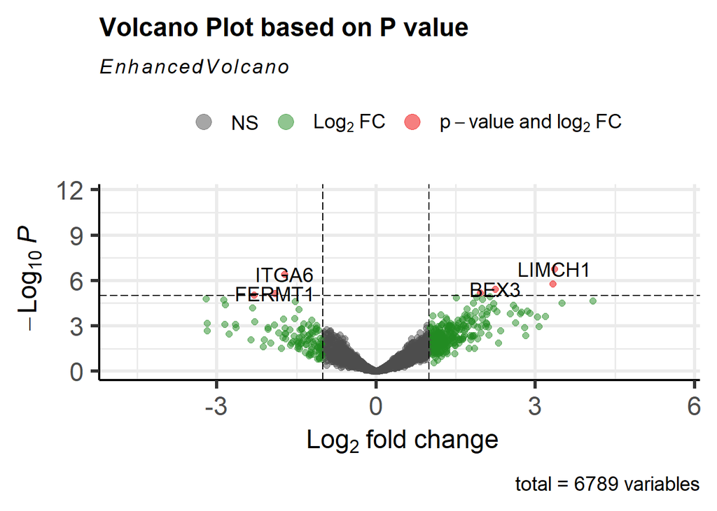

```r
# Write the data frame to a CSV file
file_path <- "~/BHK lab/kevin Project/Cholangiocarcinoma/data/Limma_Fit.csv"
write.csv(data.frame(RowNames = rownames(fit),fit), file_path, row.names = FALSE)


# #2. Volcano plot.
# Retrieve all results from the analysis
volcano_data <- topTable(fit, number=Inf)


# 2.1 Volcano Plot based on P value
EnhancedVolcano(volcano_data,
    lab = rownames(volcano_data),
    x = 'logFC',
    y = 'P.Value',
    title= 'Volcano Plot based on P value'
    )
```

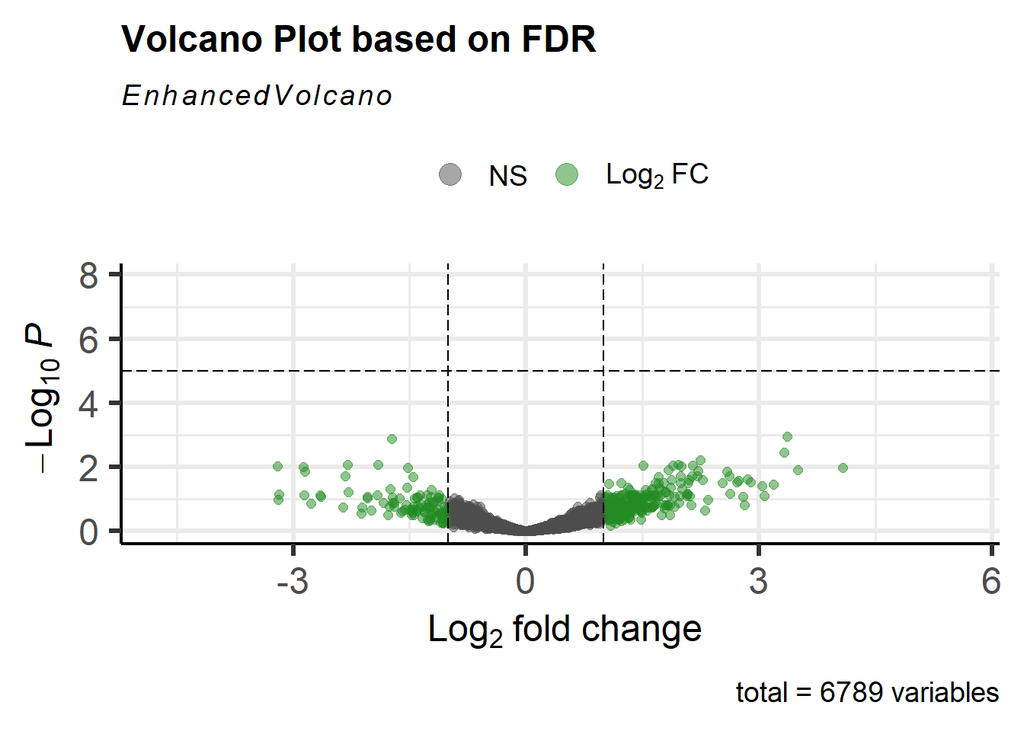

```r
# 2.2 Volcano Plot based on FDR
EnhancedVolcano(volcano_data,
    lab = rownames(volcano_data),
    x = 'logFC',
    y = 'adj.P.Val',
    title= 'Volcano Plot based on FDR')
```